# Merge Desjardins and Ashton trees

Author

Claudia Zirión-Martínez

Published

February 10, 2025

## Setup

Libraries

```r
library(RRphylo)
library(manipulate)
library(ape)
library(phytools)
library(ggtree)
library(tidyverse)
library(RColorBrewer)
library(ggnewscale)
library(patchwork)
source("scripts/metadata_colors.R")
```

### Paths

Metadata

```r
metadata_all_path <-
    "../Crypto_Desjardins_Ashton/results/02.Dataset_all/metadata.csv"
```

Trees

```r
# Input
desj_tree_path <-
    "data/raw/CryptoDiversity_Desjardins_Tree.tre"
ashton_tree_path <-
    "data/raw/2017.06.09.all_ours_and_desj.snp_sites.mod.fa.cln.tree"
ploidy_path <-
    "results/tables/ploidy.tsv"
ashton_mapping_stats_path <-
    "../Crypto_Ashton/results/02.Dataset_all/depth_quality/mapping_stats.tsv"
desjadins_runs <-
    "../Crypto_Desjardins/config/runs_table.tsv"

# Output
desj_tree_out_path <-
    "data/processed/tree_desjardins.newick"
ashton_tree_out_path <-
    "data/processed/tree_ashton.newick"
merged_tree_out_path <-
    "data/processed/tree_merged.newick"
metadata_output <- "data/processed/metadata_all.csv"
```

Plots

```r
desj_tree_out_plot <-
    "results/figures_extra/tree_desjardins.png"
desj_tree_out_plot2 <-
    "results/figures_extra/tree_desjardins_2.svg"
desj_tree_out_plot_pdf <-
    "results/figures_extra/tree_desjardins.pdf"
ashton_tree_out_plot <-
    "results/figures_extra/tree_ashton.png"
ashton_tree_out_plot_pdf <-
    "results/figures_extra/tree_ashton.pdf"
merged_tree_plot <-
    "results/figures_extra/tree_merged.png"
merged_tree_plot_pdf <-
    "results/figures_extra/tree_merged.pdf"
merged_tree_removed_plot_png <-
    "results/figures_extra/tree_merged_removed.png"
merged_tree_small_plot <-
    "results/figures_extra/tree_merged_small.png"
merged_tree_continent_plot_png<-
    "results/figures_extra/tree_merged_continent.png"
```

## Ploidy and quality

```r
ploidy <- read.delim(ploidy_path,header = TRUE)
quality <- read.delim(ashton_mapping_stats_path, header = TRUE)%>%
    select(sample, quality_warning)%>%
    filter(quality_warning == "MAPQ-Low")

H99 <- data.frame('sample'= 'GCF_000149245',
                'strain'= 'H99',
                'lineage'= 'VNI',
                'sublineage'= 'VNIb',
                'dataset'= 'Reference',
                'source'= 'Clinical',
                'mating_type'= 'α',
                'country'= 'USA',
                'continent'= 'North America')
```

## Metadata

Use the metadata table that has all (even the ones that will be excluded) the samples of Ashton and Desjardins(n = 1064).

```r
metadata <- read.delim(
    metadata_all_path,
    header=TRUE,
    sep=",") %>%
    select(strain, everything())%>%
    left_join(ploidy, by="sample")%>%
    left_join(quality, by="sample")%>%
    bind_rows(H99)%>%
    mutate(excluded = ifelse(ploidy == "non_haploid" | quality_warning == "MAPQ-Low", "yes", "no"))

metadata$excluded <- as.factor(metadata$excluded)

metadata$mating_type <-ifelse(metadata$mating_type == "", NA, metadata$mating_type)
summary <- metadata %>%
    group_by(dataset, lineage) %>%
    summarize(count = n())
summary
```

| dataset | lineage | count |
| --- | --- | --- |
| Ashton | VNI | 677 |
| Desjardins | VNBI | 122 |
| Desjardins | VNBII | 64 |
| Desjardins | VNI | 185 |
| Desjardins | VNII | 16 |
| Reference | VNI | 1 |

Write metadata file

```r
write.table(metadata, metadata_output, sep =",", quote = FALSE, row.names = FALSE, na = "" )
```

Make separate dataframes for each metadata field.

```r
metadata$sublineage <- factor(metadata$sublineage,
                            levels = c(names(sublineage_colors), "VNIa-outlier"))
metadata$country <- factor(metadata$country,
                                levels = names(country_colors))

sublineage <- metadata %>%
                filter(lineage == "VNI")%>%
                select(strain, sublineage)%>%
                column_to_rownames("strain")%>%
                droplevels()
lineage <- metadata %>%
            select(strain, lineage)%>%
            column_to_rownames("strain")
dataset <- metadata %>%
            select(strain, dataset)%>%
            column_to_rownames("strain")
source <- metadata %>%
            select(strain, source)%>%
            column_to_rownames("strain")
country <- metadata %>%
            select(strain, country)%>%
            column_to_rownames("strain")
continent<- metadata %>%
            select(strain, continent)%>%
            column_to_rownames("strain")
mating_type <- metadata %>%
            select(strain, mating_type)%>%
            column_to_rownames("strain")
ploidy <- metadata %>%
    select(strain, ploidy)%>%
    column_to_rownames("strain")
quality <- metadata %>%
    select(strain, quality_warning)%>%
    column_to_rownames("strain")
```

## Desjardins tree

Import the raw Desjardins tree

```r
desj_tree <- read.tree(desj_tree_path)
```

Reroot the tree at the middle of the branch leading to VNII

```r
VNII_root <- getMRCA(desj_tree, c("C2","C12"))
edge_length <- subset(desj_tree$edge.length, desj_tree$edge[,2] == VNII_root)
desj_tree <- reroot(desj_tree, VNII_root, edge_length/2)
```

Write rooted Desjardins tree

```r
write.tree(desj_tree, file = desj_tree_out_path)
```

Keep only the names of the countries in the Desjardins dataset to have a proper legend.

```r
country_desj <- levels(droplevels(country[rownames(country) %in% desj_tree$tip.label, ]))
```

Get lineage nodes for plot

```r
VNI_node <- getMRCA(desj_tree, c("Tu241-1","Bt164"))
VNII_node <- getMRCA(desj_tree, c("C2","C12"))
VNBI_node <- getMRCA(desj_tree, c("Tu229-1","Ftc267-2"))
VNBII_node <- getMRCA(desj_tree, c("MW-RSA3321","MW-RSA3179"))

nodes_lineages <- data.frame(
    lineage = c("VNI", "VNII", "VNBI", "VNBII"),
    mrca = c(VNI_node, VNII_node, VNBI_node, VNBII_node)
)
```

```r
VNIa4_node <- getMRCA(desj_tree, c("Ug2463","Bt164"))
VNIa5_node <- getMRCA(desj_tree, c("NRHc5025.ENR.CLIN.1","AD1-83a"))
VNIa93_node <- getMRCA(desj_tree, c("RTC1","Br795"))
VNIa32_node <- getMRCA(desj_tree, c("A4-34-6","In2632"))
VNIaX_node <- getMRCA(desj_tree, c("Bt48","MW-RSA36"))
VNIaY_node <- getMRCA(desj_tree, c("Bt18","Bt138"))
VNIb_node <- getMRCA(desj_tree, c("A1-84-14","MW-RSA722"))
VNIc_node <- getMRCA(desj_tree, c("Bt20","Bt11"))

nodes_vnisublineages <- data.frame(
    sublineage = c(
                "VNIa-4", "VNIa-5", "VNIa-93",
                "VNIa-32", "VNIa-X", "VNIa-Y",
                "VNIb", "VNIc"),
    mrca = c(
            VNIa4_node, VNIa5_node, VNIa93_node,
            VNIa32_node, VNIaX_node, VNIaY_node,
            VNIb_node, VNIc_node))
```

```r
d <- ggtree(desj_tree,
        ladderize = TRUE,
        layout = "circular",
        size = 0.09) %<+%  metadata +
    geom_tiplab(color = "black", size = 0.6, linesize = 0.05, align =TRUE)+
    geom_text(aes(label = nodes_lineages$lineage[match(node, nodes_lineages$mrca)]),
                        size = 2, , fontface = "bold",
                        hjust = 0.3, vjust = -0.5)+
    geom_hilight(data=nodes_vnisublineages,
        aes(node=mrca, fill=sublineage), alpha = 0.8)+
        scale_fill_manual(name = "Sublineage", values = sublineage_shading)+
    guides(fill = FALSE)+
    new_scale_fill()+
    geom_tree(size = 0.1)+
    geom_tippoint(aes(shape = mating_type, color = source),
                size = 0.5)+
    scale_color_manual(name = "Source", values = source_colors, na.value = "gray90")+
    scale_shape_manual(name = "MAT", values = mat_shapes, na.value = 18)+
    guides(shape = guide_legend(order = 1), #override.aes = list(linewidth = 0.01),
            color = guide_legend(override.aes = list(size = 5), order = 2))+
    geom_treescale(x=-0.03, y=0, width=0.01, fontsize =2, offset=30)
```

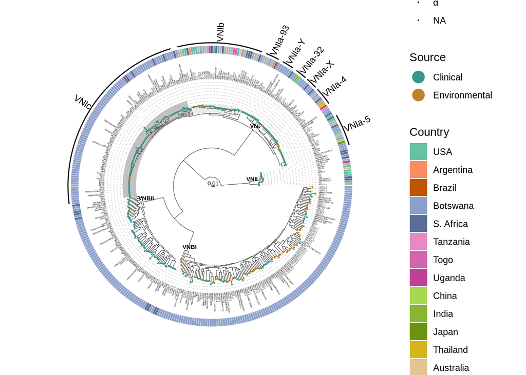

```r
dc <- gheatmap(d, country, width =.08, colnames=FALSE, offset=0.07)+
        scale_fill_manual(values=country_colors,
                      name="Country", na.translate=TRUE,
                      limits = country_desj)+
        guides(fill = guide_legend(order = 3, ncol = 1))+
    geom_cladelab(data = nodes_vnisublineages,
            mapping = aes(node = mrca, label = sublineage),
            fontsize = 3,
            align = TRUE, face = "bold",
            angle = "auto", offset = 0.11)+
    theme(legend.position = "right",
            legend.direction = "vertical")

dc
```

Save Desjardins tree plot to file.

```r
ggsave(desj_tree_out_plot, dc, height = 6.5, width = 7, units = "in", dpi = 600)
ggsave(desj_tree_out_plot_pdf, dc, height = 6.5, width = 7, units = "in", dpi = 600, device = cairo_pdf)
```

Contient and source, without tiplabels

```r
d <- ggtree(desj_tree,
        ladderize = TRUE,
        layout = "circular",
        size = 0.09) %<+%  metadata +
    geom_text(aes(label = nodes_lineages$lineage[match(node, nodes_lineages$mrca)]),
                        size = 2, , fontface = "bold",
                        hjust = 0.3, vjust = -0.5)+
    geom_tree(size = 0.1)+
    geom_treescale(x=-0.03, y=0, width=0.01, fontsize =2, offset=30)
```

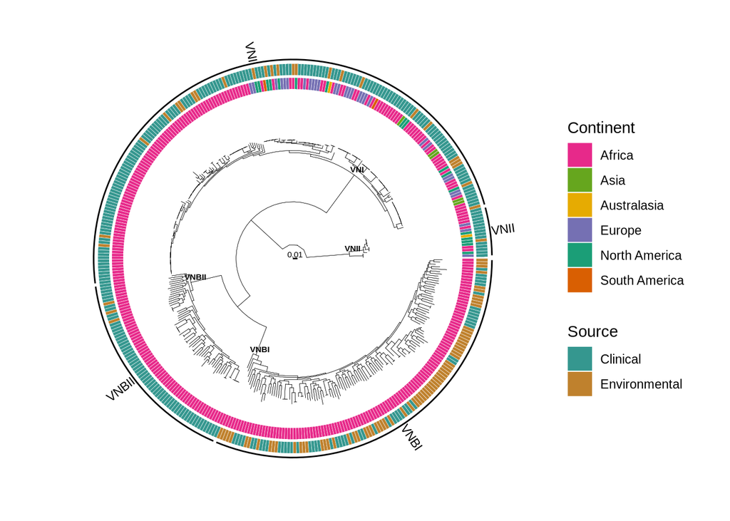

```r
dc <- gheatmap(d, continent, width =.08, colnames=FALSE, offset=0.01)+
        scale_fill_manual(values=continent_colors,
                      name="Continent", na.translate=TRUE,)+
        guides(fill = guide_legend(order = 1, ncol = 1))+
        new_scale_fill()

ds <- gheatmap(dc, source, width = 0.08, colnames = FALSE, offset = 0.04)+
        scale_fill_manual(name = "Source", values = source_colors, na.value = "gray90")+
        guides(color = guide_legend(override.aes = list(size = 5), order = 2))+
        geom_cladelab(data = nodes_lineages,
            mapping = aes(node = mrca, label = lineage),
            fontsize = 3,
            align = TRUE, face = "bold",
            angle = "auto", offset = 0.08)+
        theme(legend.position = "right",
                legend.direction = "vertical")

ds
```

```r
ggsave(desj_tree_out_plot2, ds, height = 6.5, width = 7, units = "in", dpi = 600)
```

## Ashton tree

Import the raw Ashton tree

```r
ashton_tree_unrooted <- read.tree(ashton_tree_path)
labels <- ashton_tree_unrooted$tip.label
```

Rename tips of the Desjardins samples because they have SRA run accessions in this tree but strain names in the other one

```r
metadata_runs <- read.delim(desjadins_runs, header=TRUE, sep="\t")%>%
    filter(run %in% labels) %>%
    right_join(metadata, by="sample")%>%
    mutate(run = ifelse(strain == "H99", sample, ifelse(is.na(run), alias, run)))%>%
    filter(run %in% labels)
```

```r
new_labels <- sapply(labels, function(x) {
    if (x %in% metadata_runs$run) {
        metadata_runs$strain[metadata_runs$run == x]
    } else {
        x
    }
})
```

```r
ashton_tree_unrooted$tip.label <- new_labels
```

Get the samples that are present in the tree but absent from the metadata of the full dataset

```r
setdiff(ashton_tree_unrooted$tip.label, metadata$strain)
```

```
[1] "04CN-63-018" "CNS_1465"
```

Root Ashton tree at the middle of the branch leading to VNIa

```r
VNIa_root <- getMRCA(ashton_tree_unrooted, c("AD3-95a","Tu259-1"))
edge_length <- subset(ashton_tree_unrooted$edge.length,
    ashton_tree_unrooted$edge[,2] == VNIa_root)
ashton_tree <- reroot(ashton_tree_unrooted, VNIa_root, edge_length/2)
```

Write rooted Ashton tree

```r
write.tree(ashton_tree, file = ashton_tree_out_path)
```

```r
VNIa4_node <- getMRCA(ashton_tree, c("CNS_289","04CN-30-008"))
VNIa5_node <- getMRCA(ashton_tree, c("BK153","BK37"))
VNIa93_node <- getMRCA(ashton_tree, c("04CN-65-080","04CN-65-002"))
VNIa32_node <- getMRCA(ashton_tree, c("BK68","BK11"))
VNIaX_node <- getMRCA(ashton_tree, c("04CN-63-007","BK230"))
VNIaY_node <- getMRCA(ashton_tree, c("04CN-65-073","04CN-64-081"))

VNIb_node <- getMRCA(ashton_tree, c("AD3-41a","H99"))
VNIc_node <- getMRCA(ashton_tree, c("Bt20","Bt11"))

nodes_vnisublineages <- data.frame(
    sublineage = c(
                "VNIa-4", "VNIa-5", "VNIa-93",
                "VNIa-32", "VNIa-X", "VNIa-Y",
                "VNIb", "VNIc"),
    mrca = c(
            VNIa4_node, VNIa5_node, VNIa93_node,
            VNIa32_node, VNIaX_node, VNIaY_node,
            VNIb_node, VNIc_node))
```

```r
VNIa4_node <- getMRCA(ashton_tree_unrooted, c("CNS_289","04CN-30-008"))
VNIa5_node <- getMRCA(ashton_tree_unrooted, c("BK153","BK37"))
VNIa93_node <- getMRCA(ashton_tree_unrooted, c("04CN-65-080","04CN-65-002"))
VNIa32_node <- getMRCA(ashton_tree_unrooted, c("BK68","BK11"))
VNIaX_node <- getMRCA(ashton_tree_unrooted, c("04CN-63-007","BK230"))
VNIaY_node <- getMRCA(ashton_tree_unrooted,  c("04CN-65-073","04CN-64-081"))
VNIb_node <- getMRCA(ashton_tree_unrooted, c("AD3-41a","H99"))
VNIc_node <- getMRCA(ashton_tree_unrooted,  c("Bt20","Bt11"))

nodes_vnisublineages_unrooted <- data.frame(
    sublineage = c(
                "VNIa-4", "VNIa-5", "VNIa-93",
                "VNIa-32", "VNIa-X", "VNIa-Y",
                "VNIb", "VNIc"),
    mrca = c(
            VNIa4_node, VNIa5_node, VNIa93_node,
            VNIa32_node, VNIaX_node, VNIaY_node,
            VNIb_node, VNIc_node))
```

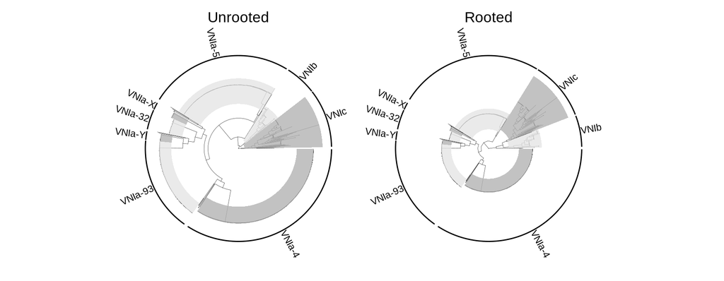

```r
pu <- ggtree(ashton_tree_unrooted, layout = "circular", size = 0.1) +
        geom_hilight(data=nodes_vnisublineages_unrooted,
            aes(node=mrca, fill=sublineage), alpha = 0.8)+
        scale_fill_manual(name = "Sublineage", values = sublineage_shading)+
        geom_cladelab(data = nodes_vnisublineages_unrooted,
            mapping = aes(node = mrca, label = sublineage),
            fontsize = 3,
            align = TRUE, face = "bold",
            angle = "auto", offset = 0.01)+
        labs(title = "Unrooted")+
        theme(legend.position = "none",
                plot.title = element_text(hjust = 0.5))

p <- ggtree(ashton_tree, layout = "circular", size =0.1)+
        geom_hilight(data=nodes_vnisublineages,
            aes(node=mrca, fill=sublineage), alpha = 0.8)+
        scale_fill_manual(name = "Sublineage", values = sublineage_shading)+
        geom_cladelab(data = nodes_vnisublineages,
            mapping = aes(node = mrca, label = sublineage),
            fontsize = 3,
            align = TRUE, face = "bold",
            angle = "auto", offset = 0.01)+
        labs(title = "Rooted")+
        theme(legend.position = "none",
                plot.title = element_text(hjust = 0.5))

pu | p
```

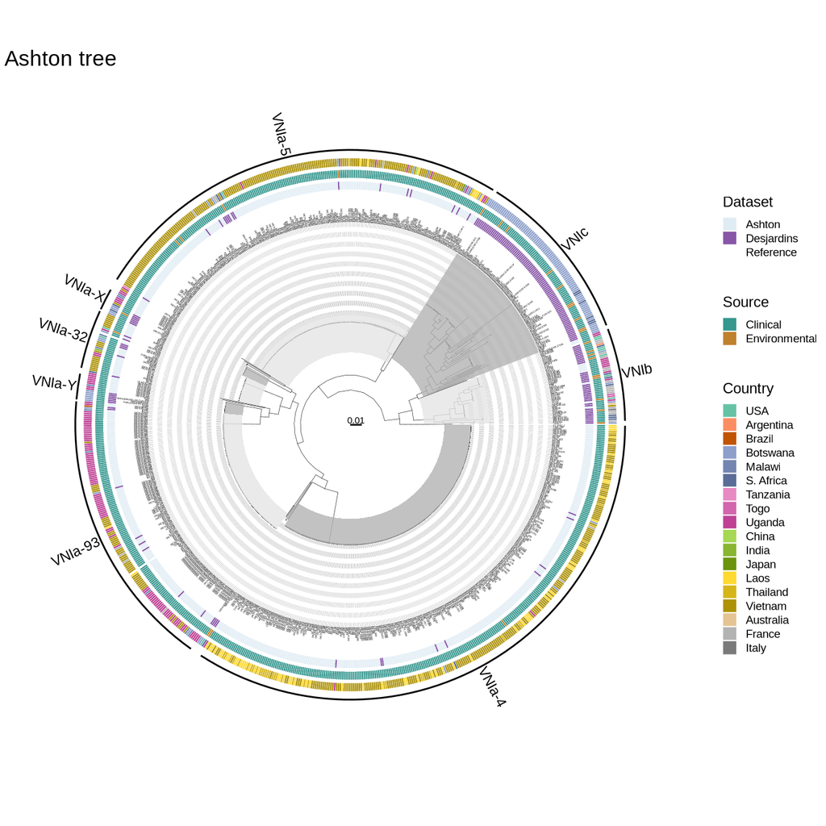

```r
m <- ggtree(ashton_tree, layout = "circular", size = 0.1) +
            geom_tiplab(aes(label = label), size = 0.5, align =TRUE,
                    linetype = "dashed", linesize = .03)+
        geom_treescale(x=-0.03, y=0, width=0.01, fontsize =2, offset=30)+
        geom_hilight(data=nodes_vnisublineages,
            aes(node=mrca, fill=sublineage), alpha = 0.8)+
        scale_fill_manual(name = "Sublineage", values = sublineage_shading)+
        guides(fill = FALSE)+
        new_scale_fill()

m1 <- gheatmap(m, dataset, width=.05, colnames=FALSE, offset=.025) +
            scale_fill_manual(values = dataset_colors, name="Dataset", na.translate = FALSE)+
            guides(fill = guide_legend(order = 1))+
            new_scale_fill()

m2 <- gheatmap(m1, source, width=.05, colnames=FALSE, offset=0.035) +
        scale_fill_manual(values = source_colors, name="Source", na.translate = FALSE)+
        guides(fill = guide_legend(order = 3))+
        labs(title = "Ashton tree")+
        new_scale_fill()

m3 <- gheatmap(m2, country, width =.05, colnames=FALSE,offset=0.045)+
    scale_fill_manual(values=country_colors,
                      name="Country", na.translate=FALSE,
                      limits = levels(country$country))+
    guides(fill = guide_legend(order =4))+
        theme(legend.position = "right",
                legend.direction = "vertical",
                legend.title = element_text(size=9),
                legend.text=element_text(size=7),
                legend.key.size = unit(0.3, "cm"),
                plot.margin = margin(0, 0, 0, 0, "cm"))+
    geom_cladelab(data = nodes_vnisublineages,
            mapping = aes(node = mrca, label = sublineage),
            fontsize = 3,
            align = TRUE, face = "bold",
            angle = "auto", offset = 0.06)

m3
```

```r
ggsave(ashton_tree_out_plot, m3, height = 6.5, width = 7, units = "in", dpi = 600)
ggsave(ashton_tree_out_plot_pdf, m3, height = 6.5, width = 7, units = "in", dpi = 600, device = cairo_pdf)
```

## Merge Desjardins and Ashton trees

Specify clades in Desjardins tree

```r
VNI <- c("Bt92", "Bt79")
VNI_node <- getMRCA(desj_tree, VNI)
VNII <- c("C2","C12")
VNII_node <- getMRCA(desj_tree, VNII)
VNB <- c("Bt7", "Bt34")
VNB_node <- getMRCA(desj_tree, VNB)
```

Get the ages of the nodes from the original Desjardins tree. This is to attempt to have a calibrated tree, but the resulting branchlengths are not accurate.

```r
edge_lengths <- node.depth.edgelength(desj_tree)
node_labels <- c(desj_tree$tip.label, desj_tree$node.label)
edge_length_mapping <- data.frame(
    node = node_labels,
    edge_length = edge_lengths,
    max_length = max(edge_lengths))
edge_length_mapping <- edge_length_mapping %>%
                        mutate(age = max_length - edge_length) %>%
                        rownames_to_column("node_id")
clade_ages <- edge_length_mapping %>%
                filter(node_id %in% c(VNI_node, VNII_node, VNB_node))
nodeages <- c("Bt92-Bt79" = clade_ages$age[clade_ages$node_id == VNI_node],
             "C2-C12" = clade_ages$age[clade_ages$node_id == VNII_node],
             "Bt7-Bt34" = clade_ages$age[clade_ages$node_id == VNB_node])
tip_ages <- edge_length_mapping %>%
                filter(node %in% metadata$strain)
tipages <- tip_ages$age
names(tipages) <- tip_ages$node
```

Remove VNI clade from Desjardins tree to use it as backtree

```r
VNI_tips <- tips(desj_tree, VNI_node)
backtree <- drop.tip(desj_tree, VNI_tips)
```

Create the reference tables

```r
reference <- data.frame(bind=c("CNS_289-BK8"),
                   reference=c("Bt7-Bt34"),
                   poly=c(FALSE))
```

Merge

```r
merged <- tree.merger(backbone = backtree,
                        data=reference,
                        source.tree = ashton_tree,
                        plot=FALSE,
                        node.ages = nodeages,
                        tip.ages = tipages)
```

Write merged tree to file

```r
write.tree(merged, file = merged_tree_out_path)
```

Get lineage and sublineage nodes for plot

```r
VNI_node <- getMRCA(merged, c("Tu241-1","UI_31647-2"))
VNII_node <- getMRCA(merged, c("C2","C12"))
VNBI_node <- getMRCA(merged, c("Tu229-1","Ftc267-2"))
VNBII_node <- getMRCA(merged, c("MW-RSA3321","MW-RSA3179"))

nodes_lineages <- data.frame(
    lineage = c("VNI", "VNII", "VNBI", "VNBII"),
    mrca = c(VNI_node, VNII_node, VNBI_node, VNBII_node)
)
```

```r
VNIa4_node <- getMRCA(merged, c("04CN-30-008","UI_31647-2"))
VNIa5_node <- getMRCA(merged, c("BMD852","BK153"))
VNIa93_node <- getMRCA(merged, c("04CN-65-080","04CN-65-002"))
VNIa32_node <- getMRCA(merged, c("BMD942","BMD2801"))
VNIaX_node <- getMRCA(merged, c("Bt48","04CN-63-007"))
VNIaY_node <- getMRCA(merged, c("04CN-65-073","Bt138"))
VNIb_node <- getMRCA(merged, c("04CN-65-096","MW-RSA722"))
VNIc_node <- getMRCA(merged, c("Bt20","Bt11"))

nodes_vnisublineages <- data.frame(
    sublineage = c(
                "VNIa-4", "VNIa-5", "VNIa-93",
                "VNIa-32", "VNIa-X", "VNIa-Y",
                "VNIb", "VNIc"),
    mrca = c(
            VNIa4_node, VNIa5_node, VNIa93_node,
            VNIa32_node, VNIaX_node, VNIaY_node,
            VNIb_node, VNIc_node))
```

```r
nodes_sublineages <- data.frame(
    sublineage = c("VNI", "VNII", "VNBI", "VNBII",
                "VNIa-4", "VNIa-5", "VNIa-93",
                "VNIa-32", "VNIa-X", "VNIa-Y",
                "VNIb", "VNIc"),
    mrca = c(VNI_node, VNII_node, VNBI_node, VNBII_node,
            VNIa4_node, VNIa5_node, VNIa93_node,
            VNIa32_node, VNIaX_node, VNIaY_node,
            VNIb_node, VNIc_node))
```

### Plot complete merged tree

Base

```r
m <- ggtree(merged,
        ladderize = TRUE,
        layout = "circular",
        branch.length = "none",
        size = 0.1) %<+%  metadata +
    geom_tiplab(color = "black", size = 0.5, offset = 0.01)+
    geom_text(aes(label = nodes_lineages$lineage[match(node, nodes_lineages$mrca)]),
                        size = 2, , fontface = "bold",
                        hjust = 1.25, vjust = -0.5)+
    geom_hilight(data=nodes_vnisublineages,
        aes(node=mrca, fill=sublineage), alpha = 0.8)+
        scale_fill_manual(name = "Sublineage", values = sublineage_shading)+
    guides(fill = FALSE)+
    new_scale_fill()+
    geom_tree(size = 0.1)+
    geom_tippoint(aes(color = dataset),
                size = 0.3)+
    scale_color_manual(values = dataset_colors, name="Dataset", na.translate = FALSE)+
    guides(color = guide_legend(override.aes = list(size = 5), order = 1))

mc <- m + geom_cladelab(data = nodes_vnisublineages,
            mapping = aes(node = mrca, label = sublineage),
            align = TRUE, face = "bold",
            angle = "auto", offset = 3)
```

With country , MAT, and source

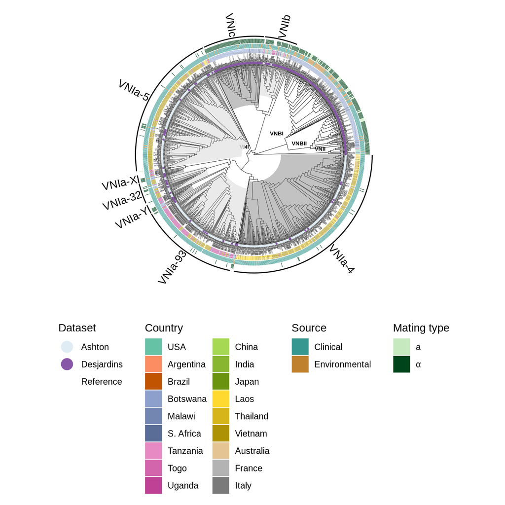

```r
m1 <- gheatmap(m, country, width =.05, colnames=FALSE,offset=3)+
    scale_fill_manual(values=country_colors,
                      name="Country", na.translate=FALSE,
                      limits = levels(country$country))+
    guides(fill = guide_legend(order = 2, ncol = 2))+
    new_scale_fill()

m2 <- gheatmap(m1, source, width=.05, colnames=FALSE, offset=5) +
        scale_fill_manual(values = source_colors,
            name="Source", na.translate = FALSE)+
        guides(fill = guide_legend(order = 3))+
        new_scale_fill()

m3 <- gheatmap(m2, mating_type, width=.05, colnames=FALSE, offset=7) +
        scale_fill_manual(values = mat_colors,
            name="Mating type", na.translate = FALSE)+
        guides(fill = guide_legend(order = 4))+
        new_scale_fill()+
    geom_cladelab(data = nodes_vnisublineages,
            mapping = aes(node = mrca, label = sublineage),
            align = TRUE, face = "bold",
            angle = "auto", offset = 10)+
    theme(legend.position = "bottom", legend.direction = "vertical")
m3
```

```r
ggsave(merged_tree_plot, m3, height = 10, width = 10, units = "in", dpi = 600)
ggsave(merged_tree_plot_pdf, m3, height = 10, width = 10, units = "in", dpi = 600, device = cairo_pdf)
```

Show samples removed by ploidy and quality

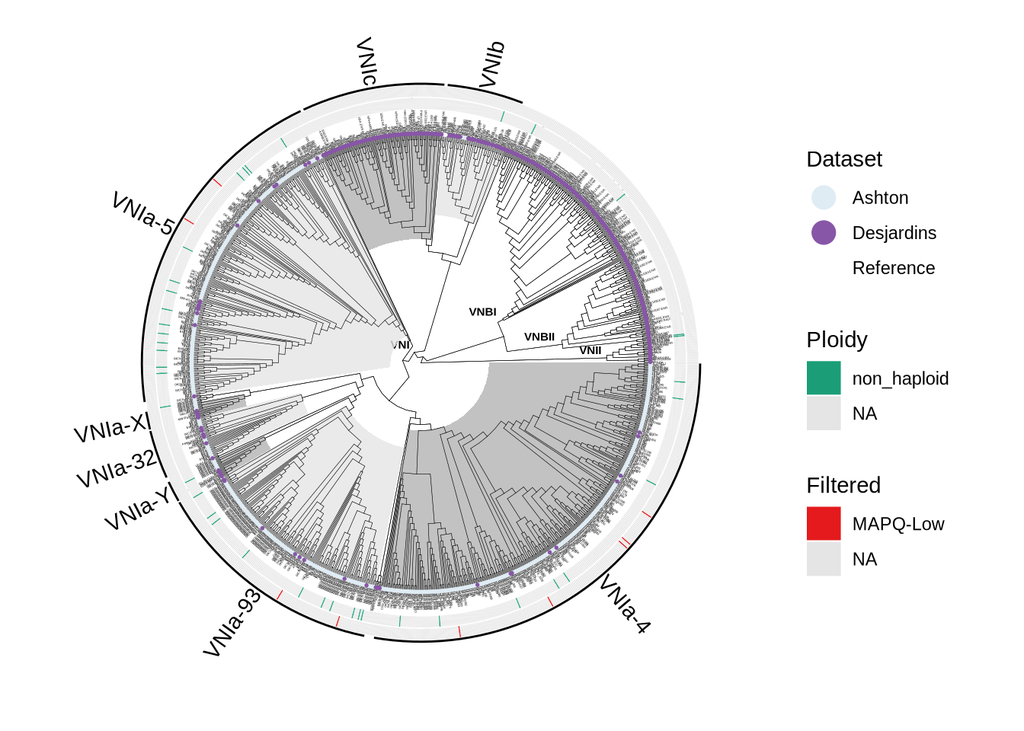

```r
mp <- gheatmap(m, ploidy, width=.05, colnames=FALSE, offset=3) +
        scale_fill_brewer(name = "Ploidy", palette = "Dark2", na.value = "gray90")+
        guides(fill = guide_legend(order = 4))+
        new_scale_fill()

mq <- gheatmap(mp, quality, width=.05, colnames=FALSE, offset=5) +
        scale_fill_brewer(name = "Filtered", palette = "Set1", na.value = "gray90") +
        guides(fill = guide_legend(order = 5))+
        new_scale_fill()+
    geom_cladelab(data = nodes_vnisublineages,
            mapping = aes(node = mrca, label = sublineage),
            align = TRUE, face = "bold",
            angle = "auto", offset = 7.3)
mq
```

```r
ggsave(merged_tree_removed_plot_png, mq, height = 10, width = 10, units = "in", dpi = 600)
```

## Plot complete merged tree without labels

Base

```r
m <- ggtree(merged,
        ladderize = TRUE,
        layout = "circular",
        branch.length = "none",
        size = 0.1) %<+%  metadata +
    geom_text(aes(label = nodes_lineages$lineage[match(node, nodes_lineages$mrca)]),
                        size = 2, , fontface = "bold",
                        hjust = 1.25, vjust = -0.5)+
    geom_hilight(data=nodes_vnisublineages,
        aes(node=mrca, fill=sublineage), alpha = 0.8)+
        scale_fill_manual(name = "Sublineage", values = sublineage_shading)+
    guides(fill = FALSE)+
    new_scale_fill()+
    geom_tree(size = 0.1)
```

With continent

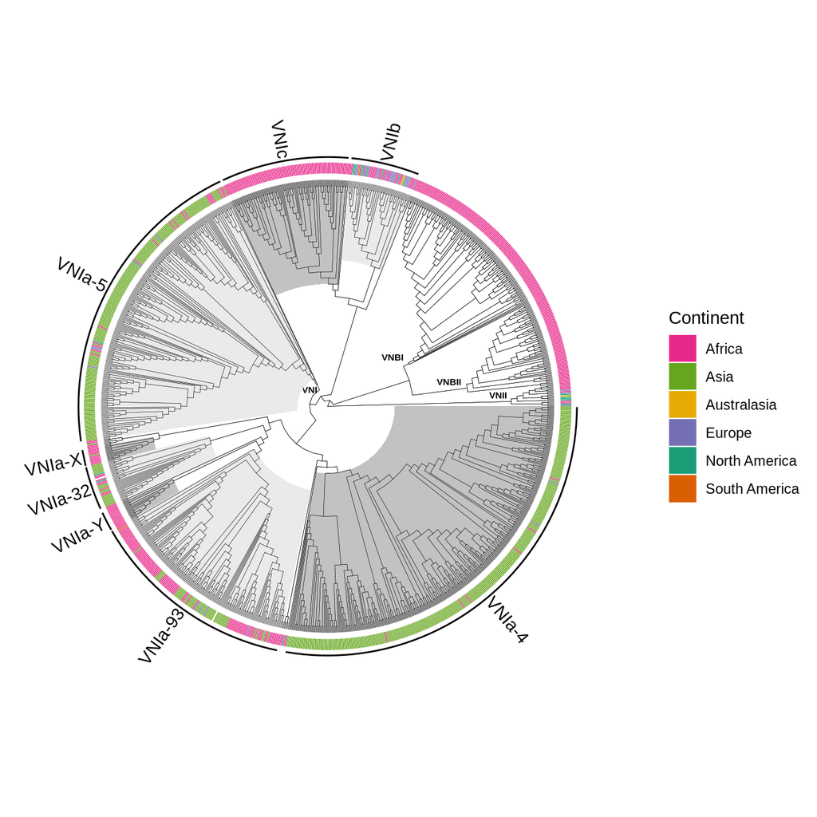

```r
mc <- gheatmap(m, continent, width=.05, colnames=FALSE, offset=0.1) +
        scale_fill_manual(values = continent_colors,
            name="Continent", na.translate = FALSE)+
    geom_cladelab(data = nodes_vnisublineages,
            mapping = aes(node = mrca, label = sublineage),
            align = TRUE, face = "bold",
            angle = "auto", offset = 3)+
    theme(legend.position = "right", legend.direction = "vertical")
mc
```

```r
ggsave(merged_tree_continent_plot_png, mc, height = 10, width = 10, units = "in", dpi = 600)
```

## Plot minimal version of the tree

Get two samples of each non-VNI lineage, VNI sublineage, and all VNIa-outlier

```r
VNIa_outlier <- metadata %>%
    filter(sublineage == "VNIa-outlier")

representatives <- c("Tu241-1","UI_31647-2","C2","C12","Tu229-1",
                    "Ftc267-2","MW-RSA3321","MW-RSA3179","04CN-30-008",
                    "UI_31647-2","BMD852","BK153","04CN-65-080",
                    "04CN-65-002","BMD942","BMD2801","Bt48",
                    "04CN-63-007","04CN-65-073","Bt138",
                    "04CN-65-096","MW-RSA722","Bt20","Bt11")
tips <- c(VNIa_outlier$strain, representatives)
```

Make a small version of the merged tree only with the tips in `tips`

```r
small_tree <- drop.tip(merged, setdiff(merged$tip.label, tips))
```

```r
VNI_node <- getMRCA(small_tree, c("Tu241-1","UI_31647-2"))
VNII_node <- getMRCA(small_tree, c("C2","C12"))
VNBI_node <- getMRCA(small_tree, c("Tu229-1","Ftc267-2"))
VNBII_node <- getMRCA(small_tree, c("MW-RSA3321","MW-RSA3179"))
VNIa4_node <- getMRCA(small_tree, c("04CN-30-008","UI_31647-2"))
VNIa5_node <- getMRCA(small_tree, c("BMD852","BK153"))
VNIa93_node <- getMRCA(small_tree, c("04CN-65-080","04CN-65-002"))
VNIa32_node <- getMRCA(small_tree, c("BMD942","BMD2801"))
VNIaX_node <- getMRCA(small_tree, c("Bt48","04CN-63-007"))
VNIaY_node <- getMRCA(small_tree, c("04CN-65-073","Bt138"))
VNIb_node <- getMRCA(small_tree, c("04CN-65-096","MW-RSA722"))
VNIc_node <- getMRCA(small_tree, c("Bt20","Bt11"))

nodes_sublineages <- data.frame(
    sublineage = c("VNI", "VNII", "VNBI", "VNBII",
                "VNIa-4", "VNIa-5", "VNIa-93",
                "VNIa-32", "VNIa-X", "VNIa-Y",
                "VNIb", "VNIc"),
    mrca = c(VNI_node, VNII_node, VNBI_node, VNBII_node,
            VNIa4_node, VNIa5_node, VNIa93_node,
            VNIa32_node, VNIaX_node, VNIaY_node,
            VNIb_node, VNIc_node))
```

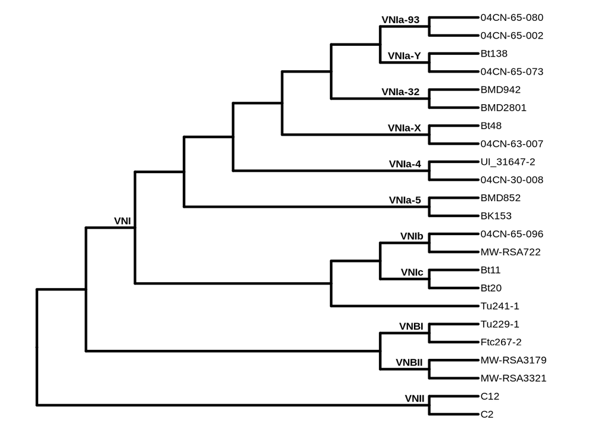

```r
p <- ggtree(small_tree, layout = "rectangular", size = 1, branch.length = "none") +
    xlim(0, 11)+
    geom_tiplab(aes(label = label),
                size = 3, align = TRUE, linetype = "dashed",
                linesize = .05,
                offset = 0, # increase offset for more space
                align.length = 2 # adjust width of the area for tiplabs
    ) +
    geom_text(aes(label = nodes_sublineages$sublineage[match(node, nodes_sublineages$mrca)]),
                size = 3, fontface = "bold",
                hjust = 1.25, vjust = -0.5)

p
```

```r
ggsave(merged_tree_small_plot, p, height = 6, width = 7, units = "in", dpi = 600)
```